# Logistic Map 综合

### 费根鲍姆常数

#### 通过分叉点计算第一费根鲍姆常数

前面我们计算了前几个分叉点位置 $r_n$，而第一费根鲍姆常数定义为：

$$ \delta = \lim_{n\to \infty} \frac{r_{n} - r_{n-1}}{r_{n+1}- r_{n}}$$

我们用前几个分叉点位置来计算，得到的 $\delta$ 随 $n$ 的变化关系为：

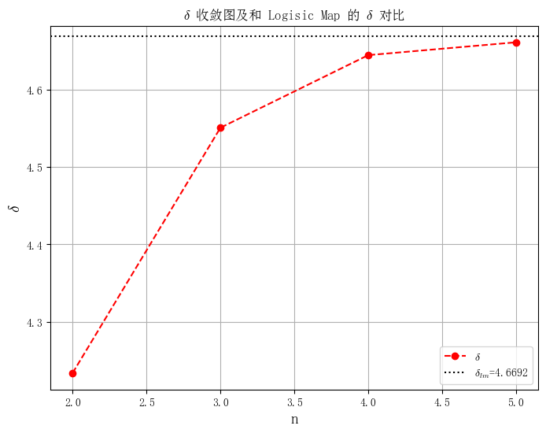

$\displaystyle \delta\approx4.661697250004176$

图中 $\delta_{lm}$ 是课件中 Logistic Map 的费根鲍姆常数，其为：

$$ \delta_{lm} = 4.6692016\dots $$

而我们通过计算得到的映射 $x_{n+1} = r-x^2_n$ 的费根鲍姆常数估计值为：

$$ \delta \approx 4.66169725 $$

两者的相对误差为：

$$ \frac{| \delta-\delta_{lm} |}{\delta_{lm}} \approx 0.16 \% $$

可见二者十分接近！且由于分叉点计算的数量较小，计算出的常数根据收敛趋势判断应该是偏小的，实际的值应该更接近 Logistic Map 的费根鲍姆常数.

#### 通过超稳定环计算第第一、二费根鲍姆常数

前面我们计算费根鲍姆常数是使用了前面找到的分叉点，但是有一个问题限制了精度：临界慢化. 具体而言，在接近分叉点的位置时，$x_n$ 收敛很慢，导致我们需要计算大量步骤后才能得到具体的周期数，同时，也导致了周期数的难以计算和准确性较低，从而限制了找到的分叉点数量，并使得计算的费根鲍姆常数精度一般.

而费根鲍姆常数除了使用分叉点来计算外，还可以使用超稳定环的位置来计算. 具体而言，对于映射 $x_{n+1} = r - x^2_{n}$，其超稳定环出现在 $x^*=0$ 处（此时导数为 $0$），此时费根鲍姆常数定义为：

$$ \delta = \lim_{n\to\infty} \frac{R_n - R_{n-1}}{R_{n+1} -R_n} $$

其中 $R_n$ 为 $2^n$ 的超稳定环出现时的 $r$. 同时还有第二费根鲍姆常数，其定义为：

$$ \alpha = - \lim_{n\to\infty} \frac{d_n}{d_{n+1}} $$

其中 $d_n$ 为超稳定环中离 $x^*=0$ 最近的点到 $x^*=0$ 的 距离.

超稳定环相比分叉点很容易搜索，这是因为我们可以直接以 $0$ 为起点，迭代 $n$ 次，检测最后是否为 $0$（或者在 $0$ 附近），每给定一个 $r$，只需要迭代 $n$ 次，不需要先让 $x_n$ 收敛，从而没有临界慢化问题，大大降低了计算量. 从而使得更精细的搜索成为可能.

而搜索超稳定环还是使用之前的初筛+细化的思路，原先的问题转为寻找 $f^n(0)=0$ 时的 $r$，因此，初筛的思路如下：

- 给定范围 $[a,b]$，其中 $b=a+\Delta r$，$\Delta r$ 为一次搜索的范围
- 计算 $f^n(a)$ 和 $f^n(b)$，如果同号，则移动到下一个步长，如果异号，则记录 $[a,b]$，并进行细化得到 $R_n$
- 新的 $a$ 定义为 $R_n + \Delta r'$，保证已经搜索过的不会再次被搜索.

而细化还是使用二分法，根据 $f^n((a+b)/2)$ 决定区间收缩方向，这里不再赘述.

通过上述方法，我们可以找到各个超稳定环出现的位置：

```
周期 2    -> R2  = 1.000000000000000
周期 4    -> R3  = 1.310702641336833
周期 8    -> R4  = 1.381547484432061
周期 16   -> R5  = 1.396945359704560
周期 32   -> R6  = 1.400253081214783
周期 64   -> R7  = 1.400961962944842
周期 128  -> R8  = 1.401113804939775
周期 256  -> R9  = 1.401146325826947
周期 512  -> R10 = 1.401153290849924
周期 1024 -> R11 = 1.401154782546614
```

对于上面的每一个 $R_n$，我们都可以找到其最后稳定轨道的每一个点，并得到最靠近 $0$ 的点（除了 $0$ 外），从而计算 $d_n$：

```
周期 1    -> R1  = 0.000000000000000, d1  = 0.000000000000000
周期 2    -> R2  = 1.000000000000000, d2  = 1.000000000000000
周期 4    -> R3  = 1.310702641336833, d3  = 0.407238772670518
周期 8    -> R4  = 1.381547484432061, d4  = 0.163425362208270
周期 16   -> R5  = 1.396945359704560, d5  = 0.065363373186764
周期 32   -> R6  = 1.400253081214783, d6  = 0.026121261182502
周期 64   -> R7  = 1.400961962944842, d7  = 0.010436922716251
周期 128  -> R8  = 1.401113804939775, d8  = 0.004169968060263
周期 256  -> R9  = 1.401146325826947, d9  = 0.001666053648770
周期 512  -> R10 = 1.401153290849924, d10 = 0.000665647584942
周期 1024 -> R11 = 1.401154782546614, d11 = 0.000265949726287
```

综上，我们可以绘制通过超稳定环得到的两个费根鲍姆常数的收敛过程：

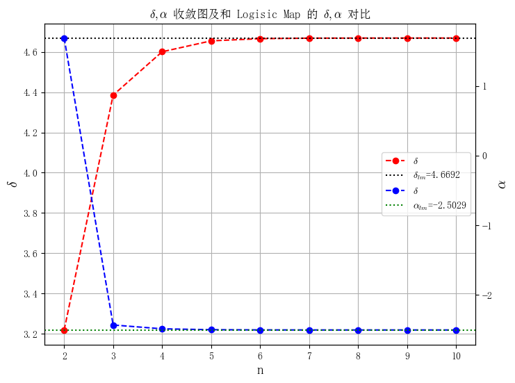

$\displaystyle \delta\approx4.669195170819541$

$\displaystyle \alpha\approx-2.5029057378387867$

图中 $\delta_{lm},\alpha_{lm}$ 是课件中 Logistic Map 的两个费根鲍姆常数，其为：

$$ \delta_{lm} = 4.669201609\dots,\quad \alpha_{lm} = -2.502907875$$

而我们通过计算得到的映射 $x_{n+1} = r-x^2_n$ 的费根鲍姆常数估计值为：

$$ \delta \approx 4.66919517, \quad \alpha \approx -2.502905738 $$

两者的相对误差为：

$$ \frac{| \delta-\delta_{lm} |}{\delta_{lm}} \approx 1.4 \times 10^{-6} ,\quad \frac{| \alpha-\alpha_{lm} |}{\alpha_{lm}} \approx 8.5 \times 10^{-7} $$

可见二者及其接近，这进一步说明了映射 $x_{n+1} = r - x^2_{n}$ 的两个费根鲍姆常数和原来的 Logistic Map 相同，同时按照不同方式得到的费根鲍姆常数也相同（通过倍周期分叉点和超稳定环）

## 选做内容：数值计算李雅普诺夫指数

### 思路

要数值计算李雅普诺夫指数，就要回归李雅普诺夫指数的原始定义，即定初始点 $x_0$ 和微扰后的点 $x_0 + \delta_0$，分别进行迭代，其距离满足：

$$ \delta_n = \mathrm{e}^{\lambda n} \delta_0 $$

其中 $\lambda$ 即为李雅普诺夫指数.

上式又可以写为：

$$ \lambda = \frac{1}{n} \ln \frac{\delta_n}{\delta_0} $$

而上式成立的条件是 $\delta_n$ 满足（至少近似满足）：

$$ \delta_n = \mathrm{e}^{\lambda n} \delta_0 $$

因此，我们可以先绘制不同情况下 $\delta_n / \delta_0$ 随 $n$ 的变化（取 $r=0.2,r=0.75,r=1.7$），分别对应 $\lambda <0,\lambda=0,\lambda>0$ 三种情况

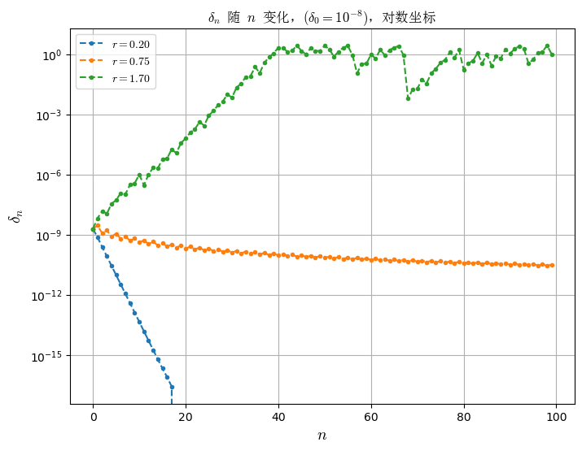

可以看到，对于 $\lambda < 0$ 和 $\lambda=0$，其 $\delta_n$ 确实基本符合 $\delta_n = \mathrm{e}^{\lambda n} \delta_0$（在图中表现为一条直线）

但是，对于 $\lambda >0$，其只在前面的一段距离近似成直线，在一定的 $n$ 后出现了拐点，使得不满足于我们原始的假设（实际上李雅普诺夫指数的定义本身也只在 $\delta$ 是围绕也就是 $\delta \ll 0$ 的情况下成立，当 $\delta_n$ 较大时这个条件就不成立了）

因此，我们的计算思路如下：

- 给定 $x_0$，迭代 $n_{\text{warm}}$ 次，去掉暂态过程.
- 构造 $x_p$ 和 $x'_p = x_p + \delta_0$，迭代计算 $n_{\text{renorm}}$ 次
- 计算此时的 $\delta_n = |x_p - x'_p|$，计算 $\ln(\delta_n / \delta_0)/n_{\text{renorm}}$ 并累加到 $S$ 中，重复第二第三步 $N$ 次
- $\lambda = S/N$

### 实现和对比

运用上述方法，我们计算全参数范围的李雅普诺夫指数：

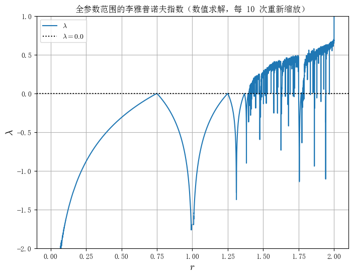

可以看到和原先通过解析方式得到的全参数范围的李雅普诺夫指数相似（除了在 $r=2.0$ 处有一个凸起在原先的图像没有）. 我们将两者叠加显示.

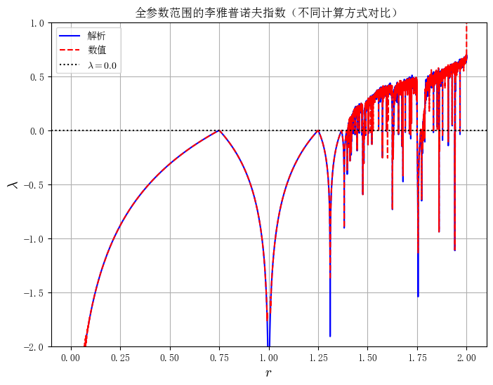

我们绘制两者的差的曲线：

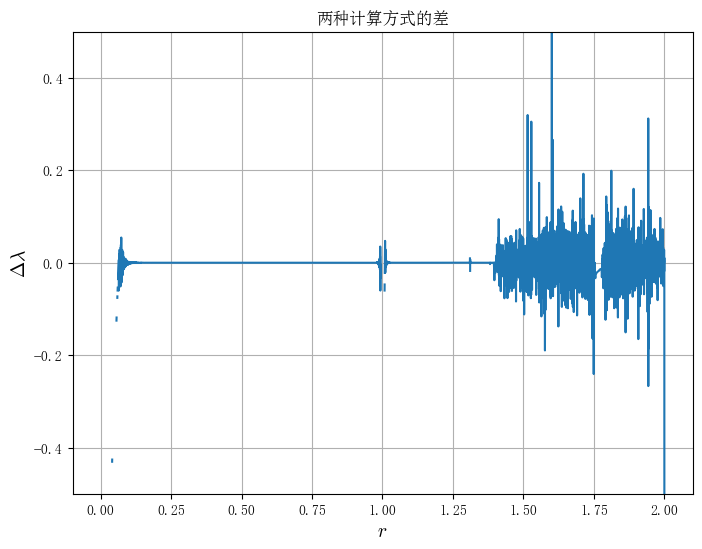

可以发现，相差较大的部分主要在超稳定环（此时 $\lambda$ 应该为 $-\infty$，但是由于数值精度限制，不可能得到 $-\infty$）.

同时，相差较大的还有在混沌区.（可能是因为在混沌区本身李雅普诺夫指数变化很快？）

而在其他参数，两者均比较吻合.

## 结论

### 解析求解周期一和周期二轨道

当 $0 < r < \frac{3}{4}$ 时，系统有稳定的周期一轨道：

$$ \dots \to \frac{\sqrt{4r+1}-1}{2} \to \dots $$

其中吸引域为（Q：可否进一步证明确实是吸引域？需要更好的放缩或者估计？）

$$| x_0 | < \frac{\sqrt{4r+1}+1}{2}$$

当 $\frac{3}{4} < r < \frac{5}{4}$ 时，系统有稳定的周期二轨道：

$$ \dots \to \frac{1+\sqrt{4r-3}}{2} \to \frac{1-\sqrt{4r-3}}{2} \to \dots $$

其中吸引域为

$$| x_0 | < \frac{\sqrt{4r+1}+1}{2}$$

同时，对于周期二，其两条轨道各自的吸引域呈现复杂的结构，其越靠近整体的吸引域边界，吸引域变化越快（Q：可否给出解析通式？）

### 全周期分叉图

映射 $x_{n+1} = r - x_{n}^2$ 的全周期分叉图如下：

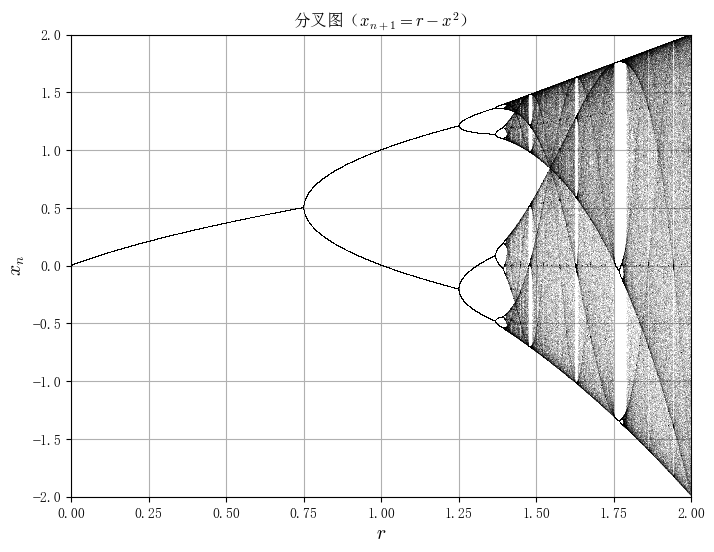

其中周期三出现在 $r=\frac{7}{4}$ 处（解析求解），周期五大约出现在 $r \approx 1.625$ 处.

### 全参数范围李雅普诺夫指数

映射 $x_{n+1} = r - x_{n}^2$ 的全参数范围李雅普诺夫指数如下（通过解析方式求解）：

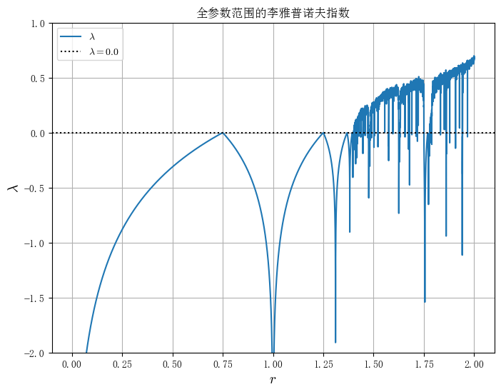

### 倍周期分叉点，$r_{\infty}$，费根鲍姆常数

映射 $x_{n+1} = r - x_n^2$ 的前几个分叉点如下（初筛+0.618 法）：

| 分叉点 | 1→2 | 2→4 | 4→8 | 8→16 | 16→32 | 32→64 |
| --- | --- | --- | --- | --- | --- | --- |
| 估计值 | 0.749965 | 1.249983 | 1.368091 | 1.394043 | 1.399630 | 1.400828 |

$r_{\infty}$ 为（初筛+二分法）：

$$ r_{\infty} \approx 1.40115522\dots $$

通过分叉点估计的费根鲍姆常数为：

$$ \delta \approx 4.66169725 $$

与上次作业的 Logistic Map 的费根鲍姆常数的相对偏差为 $0.16\%$

同时，还尝试了通过超稳定环来计算两个费根鲍姆常数，其中前几个超稳定环位置为（初筛+二分法）：

| 周期 | 2 | 4 | 8 | 16 | 32 | 64 | 128 | 256 | 512 | 1024 |
| --- | --- | --- | --- | --- | --- | --- | --- | --- | --- | --- |
| 估计值 | 1.000000 | 1.310703 | 1.381547 | 1.396945 | 1.400253 | 1.400962 | 1.401114 | 1.401146 | 1.401153 | 1.401155 |

通过超稳定环估计的费根鲍姆常数为：

$$ \delta \approx 4.66919517, \quad \alpha \approx -2.502905738 $$

与 Logistic Map 的相对偏差为：$1.4\times 10^{-6}$ 和 $8.5 \times 10^{-7}$

因此，可以认为映射 $x_{n+1} = r - x_{n}^2$ 的两个费根鲍姆常数和 Logistic Map 相同.

同时，由于分叉点存在临界慢化效应，因此通过分叉点计算费根鲍姆常数相比通过超稳定环计算更麻烦，精度更低，计算量更大.

### 选作内容：数值计算李雅普诺夫指数

通过数值计算全参数范围的李雅普诺夫指数如下（间隔一定次数重新设 $\delta$）

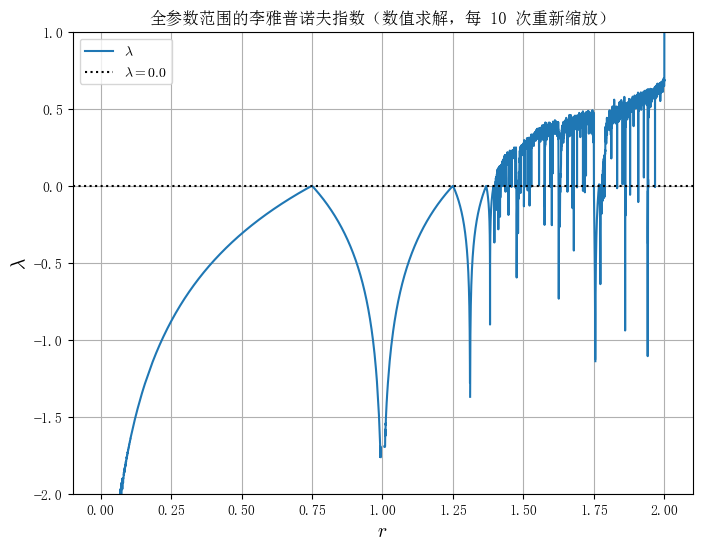

上面数值计算的结果和解析的相似，除了在 $r=2$ 附近有一个凸起（Why？暂时没想到可能的原因. 数值误差？）

## 参考资料

- Walter Rudin, 数学分析原理 (Principles of Mathematical Analysis), 3rd ed. §9.3 凝缩原理（也就是压缩映射原理）
- Steven. H. Strogatz, 非线性动力学与混沌 (Nonlinear Dynamics and Chaos), 2nd ed. §10.5, §10:练习 10.6.1
- 部分代码编写时使用 Fitten Code AI 进行补全
- 代码实现中使用 Google Gemini AI 查询了一些函数的用法.

## 致谢

感谢 9-26 所有在课后讨论李雅普诺夫指数的同学，上述讨论中数值计算李雅普诺夫指数的方法在本次作业中有所体现.（虽然后面的讨论我在符号计算中使用错了函数，将 `fn` 当成 `f` 导数实际计算的是 `fn` 的导数（也就是经过 $n$ 次迭代的函数的导数）导致给出了错误的结论. 在此表示抱歉. QAQ）

## 附一：问题

（下面的问题除了包含个人能力有限不知道如何解决的问题外，也包含一些受限于时间暂时没有探索的问题）

- 动力学上：
  - 如何分析靠近周期二吸引域边界时出现的不同轨道吸引域的快速变化？这种变化速率是否也满足某种分布（比如给定一个 $r$，其每个“条带”的宽度随条带编号 $k$ 是否也是某种指数关系？）
  - 上面这种轨道吸引域的快速变化是否和后面的混沌有关（相当于混沌区是周期 $n$（$n\to\infty$）的轨道，有 $n$ 条细分的轨道，因此条带宽度非常窄，趋向于 $0$，从而使得由于扰动由于误差等原因很容易在不同条带之间“跳跃”，导致最后行为的随机）
  - $x_{n+1} = r - x_{n}^2$ 和 Logistic Map 有相似分叉图，费根鲍姆常数的原因？一种可能的想法是这两者相当于对 $x$ 进行线性变换 $ax+b$，这个过程是不改变动力学性质的（但是很显然这里 $a,b$ 涉及 $r$）
- 数学上：
  - 对于周期一、周期二整体的吸引域，能否通过合理的估计和放缩，借助压缩映射原理来证明其吸引域？或者有无其他方法证明？是否能证明？
- 数值计算上：
  - 通过数值方式得到的李雅普诺夫指数在 $r=2$ 附近有个凸起的原因？是有具体的动力学原因还是纯粹的数值误差？
  - 如何较好地估计数值计算得到结果的有效位数？（除了看收敛曲线通过不同迭代次数计算结果的差值来估计精度外，是否有其他方式估计？）
  - 如何大致确定每一步计算需要的精度要求？（比如我希望得到的费根鲍姆常数有 $n$ 位有效位数，能否估计要求分叉点有多少位有效位数？再然后如何控制参数使得确实能得到这么多有效位数？）

## 附二：学习心得

- 解析，数值计算一维系统李雅普诺夫指数的方法，计算一维系统分叉点，超稳定环的方法
- 二分法，0.618 法等求根，优化方法在具体科学计算中的应用
- 不同方法常常能带来不同的计算难度